# 『Stataによる計量政治学』（浅野正彦, 矢内勇生)：Rによる分析

Yuki Yanai

September 19, 2014 (rev. June 5, 2015)

# 第9章 変数間の関連性

準備として、作業ディレクトリを指定する。 作業ディレクトリの指定には`setwd()`関数を利用する。 ディレクトリへのパス（引用符の中身）は、各自で設定する。

```r
setwd("~/projects/Stata-R/")
```

続いて、分析用のデータ (hr96-09.dta) を読み込み、内容を確認する （第5章のRによる分析で作った hr96-09labeled.dat を使ってもよい。）。 データセットは、作業ディレクトリ内のdataフォルダ（ディレクトリ）にあるものとする。

```r
library("foreign")
HR <- read.dta("data/hr96-09.dta")
## hr96-09labeled.dat を使う場合は、
## load("data/hr96-09.dat")
##   HR <- load("data/hr96-09.dat") ではない！！！
# head(HR)   ## データの確認：今回は実行しない（各自で確認してください）
```

## 9.1 カテゴリー変数間の関連

### 9.1.1 クロス集計表

表9.2 (p.158) を作る。

```r
library("dplyr")
HR09 <- filter(HR, year == 2009)            ## 2009年のデータを取り出して保存
tbl.st.wl <- with(HR09, table(status, wl))  ## status とwl のクロス表を作る
tbl.st.wl <- tbl.st.wl[1:2, 1:2]            ## status が"moto"の行と、wlが"zombie"の列を除外
addmargins(tbl.st.wl)  ## 周辺度数を加えて表示する
                       ## marginを指定しないと、行・列両方の周辺度数が加えられる
```

```
##             wl
## status       lose win Sum
##   challenger  559  81 640
##   incumbent   168 174 342
##   Sum         727 255 982
```

これで同じ表ができた。

#### 行パーセント

比率の表を作るには、まず上の方法で度数の表を作った後、`prop.table()`で比率に変換するのが簡単である。まず、表9.3 (p.158) を再現してみよう。

```r
## まず列周辺度数を加える; margin=1 で列周辺度数のみ加える
row.pr.st.wl <- addmargins(tbl.st.wl, margin = 1)
## 度数を比率に変換する; margin=1 で行パーセント
row.pr.st.wl <- prop.table(row.pr.st.wl, margin = 1)
## パーセント表示に変換する; 小数第2位までの表示にする
row.pr.st.wl <- round(100 * row.pr.st.wl, 2)
## 行周辺度数を加えて表示する; margin=2 で行周辺度数のみ加える
addmargins(row.pr.st.wl, margin = 2)
```

```
##             wl
## status        lose   win Sum
##   challenger 87.34 12.66 100
##   incumbent  49.12 50.88 100
##   Sum        74.03 25.97 100
```

これで表9.3 と同じ比率が得られた。

#### 列パーセント

同様に、列パーセントを計算する。 行パーセントで使ったコードの **margin** の値を帰ればよい。

```r
## まず行周辺度数を加える; margin=2 で行周辺度数のみ加える
col.pr.st.wl <- addmargins(tbl.st.wl, margin = 2)
## 度数を比率に変換する; margin=2 で行パーセント
col.pr.st.wl <- prop.table(col.pr.st.wl, margin = 2)
## パーセント表示に変換する; 小数第2位までの表示にする
col.pr.st.wl <- round(100 * col.pr.st.wl, 2)
## 列周辺度数を加えて表示する; margin=1 で列周辺度数のみ加える
addmargins(col.pr.st.wl, margin = 1)
```

```
##             wl
## status         lose    win    Sum
##   challenger  76.89  31.76  65.17
##   incumbent   23.11  68.24  34.83
##   Sum        100.00 100.00 100.00
```

これで表9.4 (p.159) と同じ比率が得られた。

#### 全体パーセント

全体パーセントを求めるときは、**margin** を指定しなければよい。

```r
## 度数を比率に変換する; margin=NULL（既定値）で全体パーセント
ttl.pr.st.wl <- prop.table(tbl.st.wl)
## パーセント表示に変換する; 小数第2位までの表示にする
ttl.pr.st.wl <- round(100 * ttl.pr.st.wl, 2)
## 周辺度数を加えて表示する
addmargins(ttl.pr.st.wl)
```

```
##             wl
## status        lose   win    Sum
##   challenger 56.92  8.25  65.17
##   incumbent  17.11 17.72  34.83
##   Sum        74.03 25.97 100.00
```

これで、表9.5 (p.160) と同じ比率が得られた。

### 9.1.2 $\chi^2$ 検定

#### StataR によるカイ二乗検定

まず、表9.8 (p.166) に示されている架空のデータセットを作ろう。

```r
## male とsupport という2つの変数をもつデータフレームを作り、Fakeとして保存
##   最初はすべての値が欠測 NA
Fake <- data.frame(male = rep(NA, 100), support = rep(NA, 100))
Fake$male <- rep(c(0, 1), c(50, 50))            ## male に値を入れる
Fake$support <- rep(c(1, 0, 1), c(20, 50, 30))  ## support に値を入れる
## データを確認したければ
## Fake
## または
## View(Fake)
```

このデータセットを使い、$\chi^2$ 検定を行う。 Rでは、`chisq.test()` を利用する。

```r
## イェーツの連続性補正は行わないので correct = FALSE
chisq.test(Fake$male, Fake$support, correct = FALSE)
```

```
##
##  Pearson's Chi-squared test
##
## data:  Fake$male and Fake$support
## X-squared = 4, df = 1, p-value = 0.0455
```

これで表9.9 (p.167) と同じ結果が得られた。

#### フィッシャーの直接確率計算法

まず、表9.10 (p.167) を元に架空のデータを入力する。 今回は、表（行列）として保存しよう。

```r
## 行列を作る
fake.table <- matrix(c(3, 2, 2, 1), nrow = 2, byrow = TRUE)
## 行に名前を付ける
row.names(fake.table) <- c("female", "male")
## 列に名前を付ける
colnames(fake.table) <- c("not support", "support")
## 周辺度数を加えて表示。
addmargins(fake.table)
```

```
##        not support support Sum
## female           3       2   5
## male             2       1   3
## Sum              5       3   8
```

このデータにFisherの直接確率計算法を適用する。 Rでは、`fisher.test()`を使う。

```r
## alternative で片側検定（女性の支持 > 男性の支持）を指定;
##   「女性 < 男性」　を検定するときは alternative="greater" とする
##   既定値は両側検定
fisher.test(fake.table, alternative = "less")
```

```
##
##  Fisher's Exact Test for Count Data
##
## data:  fake.table
## p-value = 0.7143
## alternative hypothesis: true odds ratio is less than 1
## 95 percent confidence interval:
##   0.00000 17.73797
## sample estimates:
## odds ratio
##  0.7772203
```

これで表9.11 (p.168) と同じ結果が得られた。

## 9.2 数量変数間の関連

### 9.2.2 相関係数を使った統計的仮説検定

ここからは、上で既に作った **HR09** というデータフレームを使って分析を進める。

選挙費用 (exp) と得票数 (vote) の関係をを調べるため、まず散布図を作る。 Rでは`plot()` 関数で散布図を描くことができる。

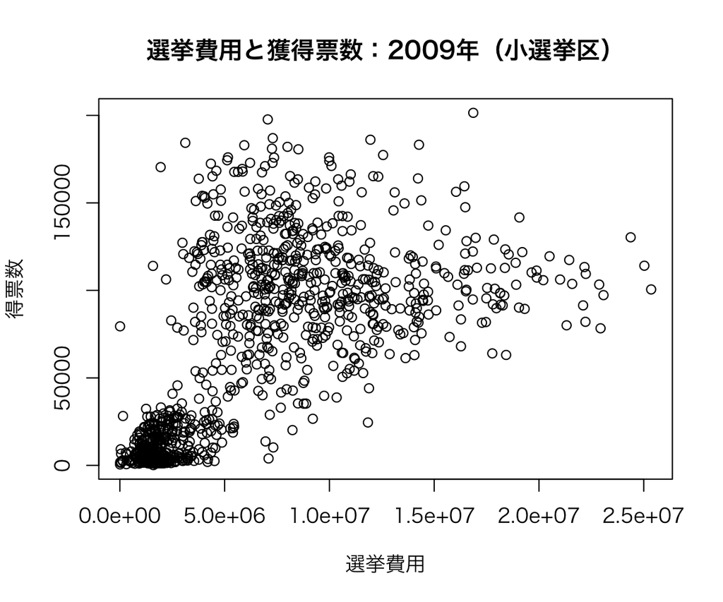

```r
plot(vote ~ exp, data = HR09, xlab = "選挙費用", ylab = "得票数",
     main = "選挙費用と獲得票数：2009年（小選挙区）")
```

このように、図9.6 (p.171) によく似た図ができる。 もう少し奇麗な図を描きたいときは、**ggplot2** を使うとよい。

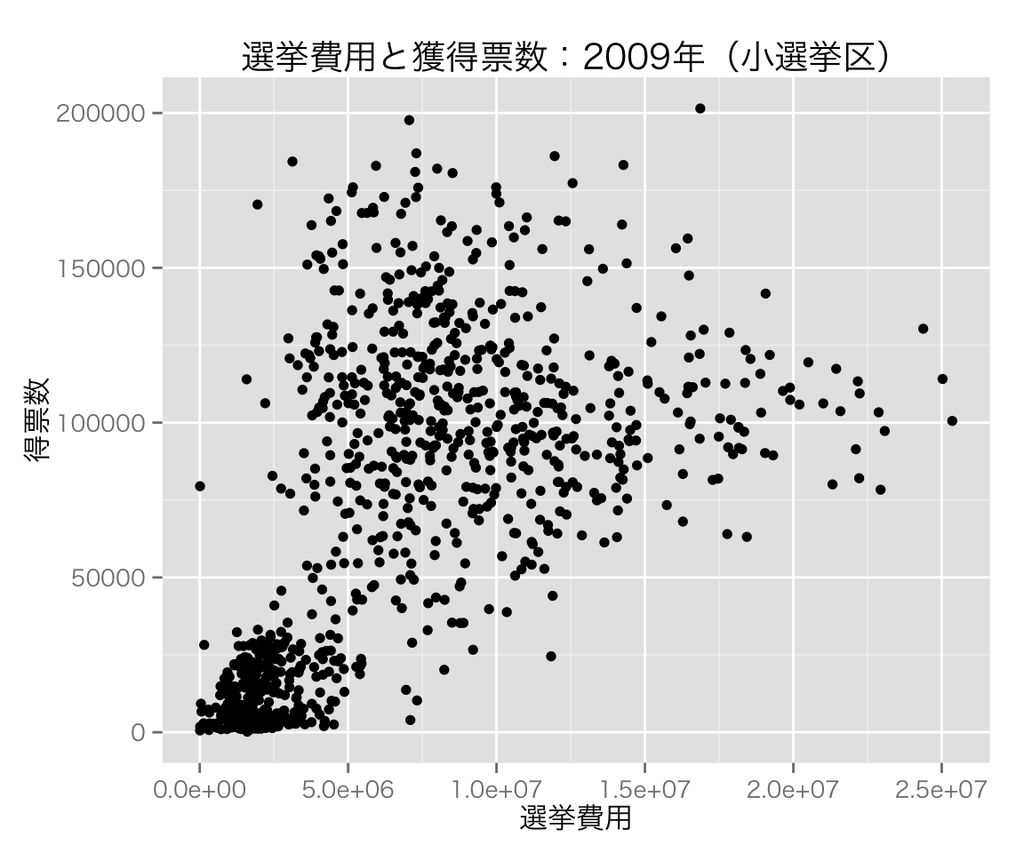

```r
## ggplot2 のインストールが必要なら
## install.packages('ggplot2')
library("ggplot2")
## Windows ユーザは次の行をコメントアウトせよ
theme_set(theme_gray(base_size=12, base_family="HiraKakuProN-W3"))
scat <- ggplot(HR09, aes(x = exp, y = vote)) +
    geom_point() +
    labs(x = "選挙費用", y = "得票数",
         title = "選挙費用と獲得票数：2009年（小選挙区）")
print(scat)
```

続いて、選挙費用と得票数の相関係数を`cor()` で求め、`cor.test()` で相関係数の$p$値を求める。

```r
with(na.omit(HR09), cor(exp, vote))       ## na.omit() で欠測値を除く
```

```
## [1] 0.6616138
```

```r
with(na.omit(HR09), cor.test(exp, vote))
```

```
##
##  Pearson's product-moment correlation
##
## data:  exp and vote
## t = 29.5549, df = 1122, p-value < 2.2e-16
## alternative hypothesis: true correlation is not equal to 0
## 95 percent confidence interval:
##  0.6274137 0.6932663
## sample estimates:
##       cor
## 0.6616138
```

これで、表9.12 (p.171) の結果が得られた。

次に、分析対象をみんなの党 (minna) に絞って同様の分析を行う。 まず、散布図を描く。

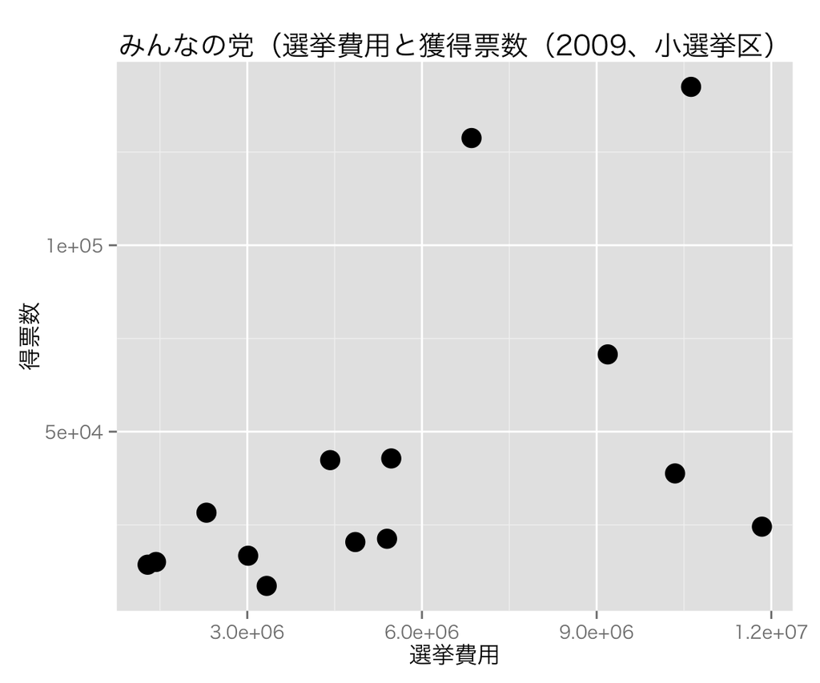

```r
scat.minna <- ggplot(filter(HR09, party == "minna"), aes(x = exp, y = vote)) +
    geom_point(size = 5) +
    labs(x = "選挙費用", y = "得票数",
         title = "みんなの党（選挙費用と獲得票数（2009、小選挙区）")
print(scat.minna)
```

これで図9.7 (p.172) と同様の図が得られた。

次に、選挙費用と得票数の相関係数を`cor()` で求め、`cor.test()` で相関係数の$p$値を求める。

```r
HR09 %>%
    filter(party == "minna", !is.na(vote), !is.na(exp)) %>%
    with(cor(exp, vote))
```

```
## [1] 0.5317654
```

```r
HR09 %>%
    filter(party == "minna", !is.na(vote), !is.na(exp)) %>%
    with(cor.test(exp, vote))
```

```
##
##  Pearson's product-moment correlation
##
## data:  exp and vote
## t = 2.1751, df = 12, p-value = 0.05033
## alternative hypothesis: true correlation is not equal to 0
## 95 percent confidence interval:
##  0.001651972 0.828569209
## sample estimates:
##       cor
## 0.5317654
```

これで表9.13 (p.173) と同じ結果が得られた。